# index

Talanyane

1/12/2024

## Summary

This entire analysis is based on the sales sample data obtained from Kaggle. The preview below shows the structure of the data. It documents a company’s profits and orders from all over the globe. The aim is to unearth what secrets and pattern may lie within the data, such data as could be instrumental for this notional company.

### pakages

```r
library(readr)
library(dplyr)
library(tidyverse)
library(lubridate)
```

### Data preview

```
## # A tibble: 10 x 21
##    order_id  order_date ship_date ship_mode  customer_name segment state country
##    <chr>     <chr>      <chr>     <chr>      <chr>         <chr>   <chr> <chr>
##  1 AG-2011-~ 1/1/2011   6/1/2011  Standard ~ Toby Braunha~ Consum~ Cons~ Algeria
##  2 IN-2011-~ 1/1/2011   8/1/2011  Standard ~ Joseph Holt   Consum~ New ~ Austra~
##  3 HU-2011-~ 1/1/2011   5/1/2011  Second Cl~ Annie Thurman Consum~ Buda~ Hungary
##  4 IT-2011-~ 1/1/2011   5/1/2011  Second Cl~ Eugene Moren  Home O~ Stoc~ Sweden
##  5 IN-2011-~ 1/1/2011   8/1/2011  Standard ~ Joseph Holt   Consum~ New ~ Austra~
##  6 IN-2011-~ 1/1/2011   8/1/2011  Standard ~ Joseph Holt   Consum~ New ~ Austra~
##  7 CA-2011-~ 2/1/2011   6/1/2011  Standard ~ Magdelene Mo~ Consum~ Onta~ Canada
##  8 IN-2011-~ 3/1/2011   3/1/2011  Same Day   Kean Nguyen   Corpor~ New ~ Austra~
##  9 ID-2011-~ 3/1/2011   9/1/2011  Standard ~ Ken Lonsdale  Consum~ Auck~ New Ze~
## 10 IZ-2011-~ 3/1/2011   7/1/2011  Standard ~ Lindsay Will~ Corpor~ Nina~ Iraq
## # ... with 13 more variables: market <chr>, region <chr>, product_id <chr>,
## #   category <chr>, sub_category <chr>, product_name <chr>, sales <dbl>,
## #   quantity <dbl>, discount <dbl>, profit <dbl>, shipping_cost <dbl>,
## #   order_priority <chr>, year <dbl>
```

### What is our best selling product?

The products on display are grouped in 3 broad categories: technology based products, office supplies and furniture. The accumulated profits for the entire 4 years by category:

```r
#what is the best selling product_category?
salesData %>%
  group_by(category) %>%
  summarize(total_profit = sum(profit)) %>%
  arrange(desc(total_profit)) %>%
  mutate(tot_profit = format(total_profit, digits = 3, big.mark = ",")) %>%
  select(category, tot_profit)
```

```
## # A tibble: 3 x 2
##   category        tot_profit
##   <chr>           <chr>
## 1 Technology      663,779
## 2 Office Supplies 518,474
## 3 Furniture       286,782
```

```r
salesData %>%
  group_by(year, category) %>%
  summarise(total_prof = sum(profit)) %>%
  mutate(annual_profits = format(total_prof, digits = 3, big.mark = ",")) %>%
  select(year, category, annual_profits)
```

```
## # A tibble: 12 x 3
## # Groups:   year [4]
##     year category        annual_profits
##    <dbl> <chr>           <chr>
##  1  2011 Furniture       " 53,697"
##  2  2011 Office Supplies " 85,997"
##  3  2011 Technology      "109,247"
##  4  2012 Furniture       " 58,133"
##  5  2012 Office Supplies "103,306"
##  6  2012 Technology      "145,977"
##  7  2013 Furniture       " 85,640"
##  8  2013 Office Supplies "149,246"
##  9  2013 Technology      "173,627"
## 10  2014 Furniture       " 89,312"
## 11  2014 Office Supplies "179,926"
## 12  2014 Technology      "234,928"
```

When we further group by sub-category we get the following ranking:

```r
salesData %>%
  group_by(category, sub_category) %>%
  summarise(sub_items_profits = sum(profit)) %>%
  arrange(desc(sub_items_profits))
```

```
## # A tibble: 17 x 3
## # Groups:   category [3]
##    category        sub_category sub_items_profits
##    <chr>           <chr>                    <dbl>
##  1 Technology      Copiers                258568.
##  2 Technology      Phones                 216717.
##  3 Furniture       Bookcases              161924.
##  4 Furniture       Chairs                 141974.
##  5 Office Supplies Appliances             141681.
##  6 Technology      Accessories            129626.
##  7 Office Supplies Storage                108461.
##  8 Office Supplies Binders                 72450.
##  9 Office Supplies Paper                   59208.
## 10 Technology      Machines                58868.
## 11 Office Supplies Art                     57954.
## 12 Furniture       Furnishings             46967.
## 13 Office Supplies Envelopes               29601.
## 14 Office Supplies Supplies                22583.
## 15 Office Supplies Labels                  15011.
## 16 Office Supplies Fasteners               11525.
## 17 Furniture       Tables                 -64083.
```

### Profit trends throughout the year

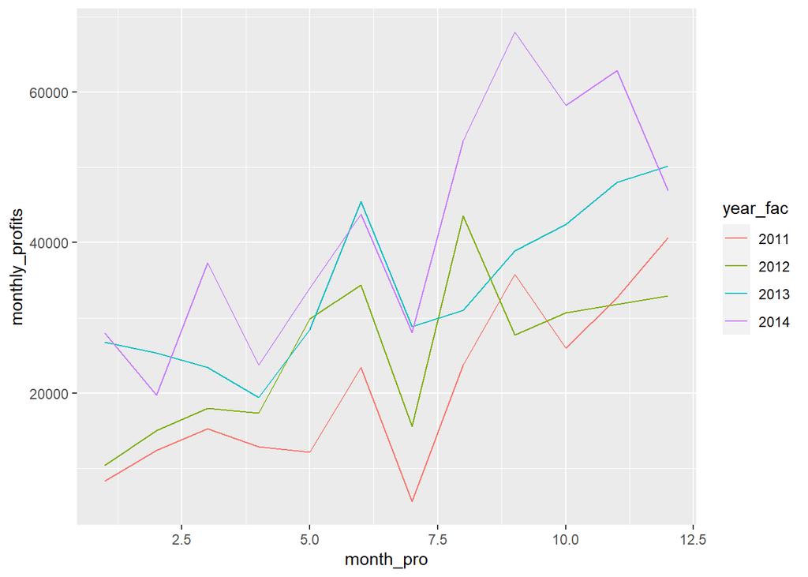

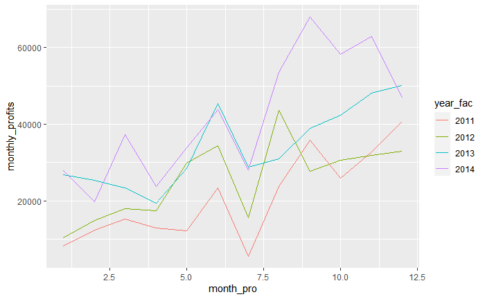

```r
monthly_psalesData <- salesData %>%
  mutate(month_pro = month(order_date)) %>%
  group_by(year, month_pro) %>%
  summarise(monthly_profits = sum(profit))

monthly_psalesData$year_fac <- as.factor(monthly_psalesData$year)

monthly_psalesData %>%
  ggplot(aes(month_pro, monthly_profits)) +
  geom_line(aes(color = year_fac))
```

### Product Category based Performance

Once again is becomes apparent that technology based products outperform the rest, though it can clearly be noted that office supplies are not far behind.

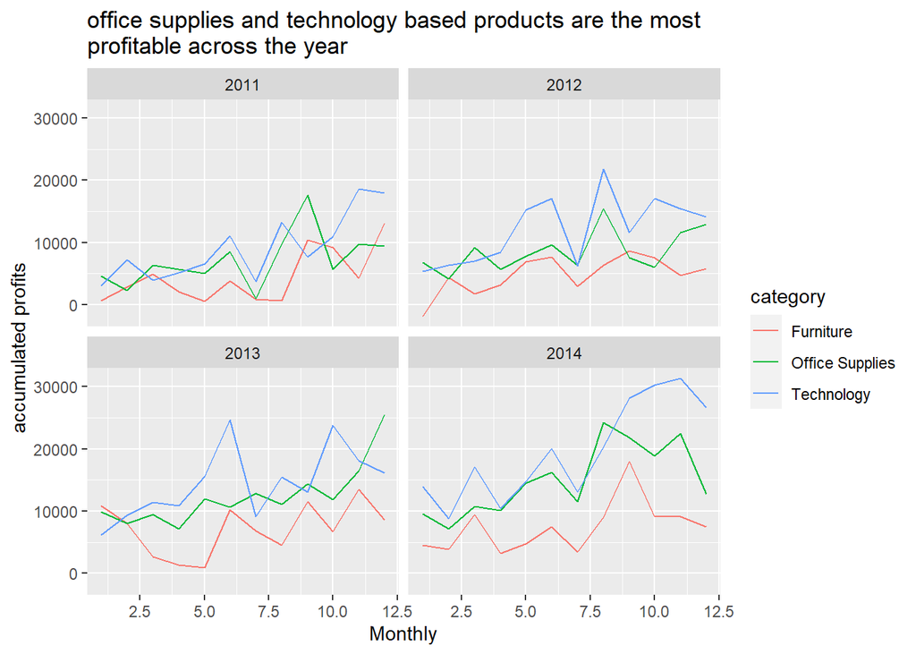

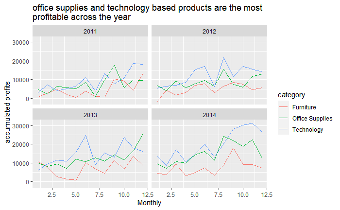

```r
salesData %>%
  mutate(permonth = month(order_date)) %>%
  group_by(year, permonth, category) %>%
  summarise(profit_M = sum(profit)) %>%
  mutate(year_fac = as.factor(year)) %>%
  ggplot(aes(permonth, profit_M, color = category)) +
  geom_line() +
  facet_wrap( ~ year_fac) +
  labs(title = paste("office supplies and technology based products are the most \nprofitable across the year"), y = "accumulated profits", x = "Monthly")
```